# Assignment 3: Sentiment Classification Reflection

# Open-Ended Reflection Questions

### 1. Training Dynamics

```
1.Overfitting or Undefitting:
```

MLP shows a overfitting sign. From the following learning curves of MLP, after 5th epoch, train loss is decreasing and roughly converge to 0.2, but the val loss is increasing after epoch 5. Also training set’s F1 score is close to 0.9, but the val is around 0.75. LSTM also shows a overfitting sign. Because traning loss keeps going down steadily, the val loss stops improving and starts to flucatuate, which means that the model is no longer getting better at predicting new data. In terms of F1 and accuracy plots, the train line keeps going up to 0.8, but the val line falttens around epoch 20.

```
2. class weights:
```

Using class weights can make the model care more about minority classes, so it usually can improve macro F1. That is the reason why both MLP and LSTM reach decent validation F1 (0.70–0.75).However, class weights may cause the training to be less stable, especially for MLP case.There are more fluctuation in validation curves, becuase the model is harder on minority, so variance will increase.

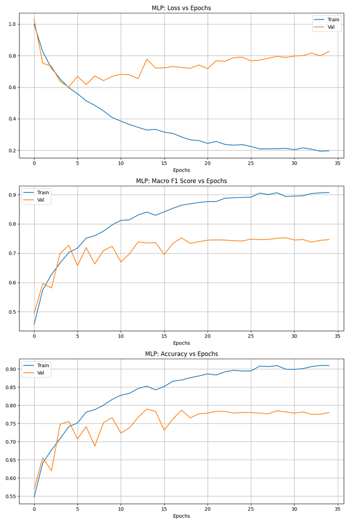

mlp_f1_learning_curves.png

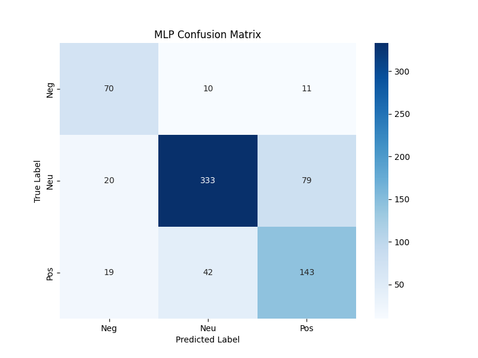

mlp_confusion_matrix.png

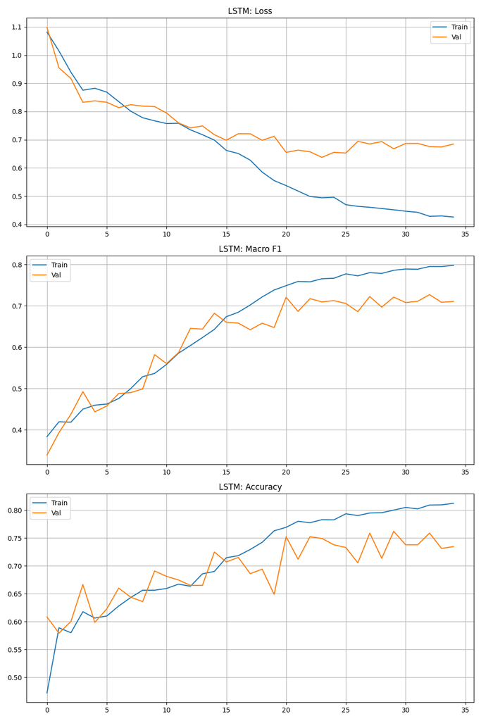

image.png

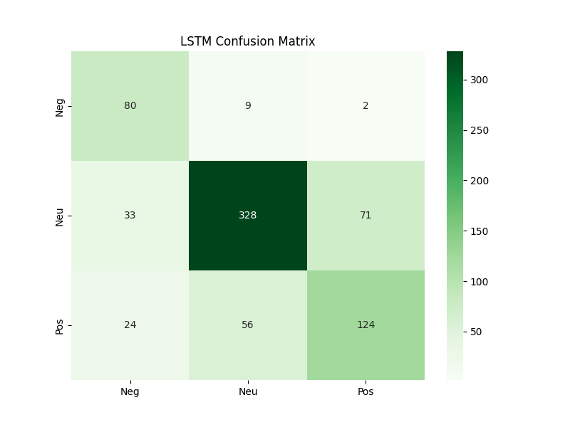

lstm_confusion_matrix.png

# 2. Model Performance and Error Analysis

[output not shown]

```
2. Which sentiment class was most frequently misclassified?
```

For both MLP and LSTM, The Neutral (Neu) class was most frequently misclassified. MLP has 20 + 79 = 99, and LSTM has 33 + 71 = 104. Both has larger number than Neg misclassified and Pos misclassified. Possible reasons will be: Neutral sentences are often close to positive or negative in wording, so it is very easy to make mistake to detect. Financial sentiment especially has subtle and euphemistic tone, which is hard to detect. Also, neutral class is usually larger, so boundary is harder to learn. Lastly,weighted loss pushes model to focus on minority classes, this can make neutral predictions noisier.

# 3. Cross-Model Comparison

```
1.How did mean-pooled FastText limit the MLP?
```

MLP uses mean-pooled FastText embeddings, so the mean-pooled FastText will averages all word vectors, which loses word order and context. This means that the mean-pooled method can not capture the subtle tone.Thus, this performs worse than sequence models that read sentences word by word.

```
2. What advantage did LSTM have over MLP?
```

LSTM will process the text sequentially, so it will keep information in word order and word dependencies. It can also learn patterns like “not good” or contrast phrases. This will help LSTM to model sentence meaning better than the simple averaging.

```
3. Did fine-tuned LLMs outperform classical models? Why?
```

Yes, BERT and GPT clearly performed best. This is because they were pretrained on massive scale of text dataset, so they understand language patterns before the fine-tuned. Their contextual embeddings capture word meaning which depends on surrounding words. This can improve the overall sentiment classification.

[output not shown]

bert plot:

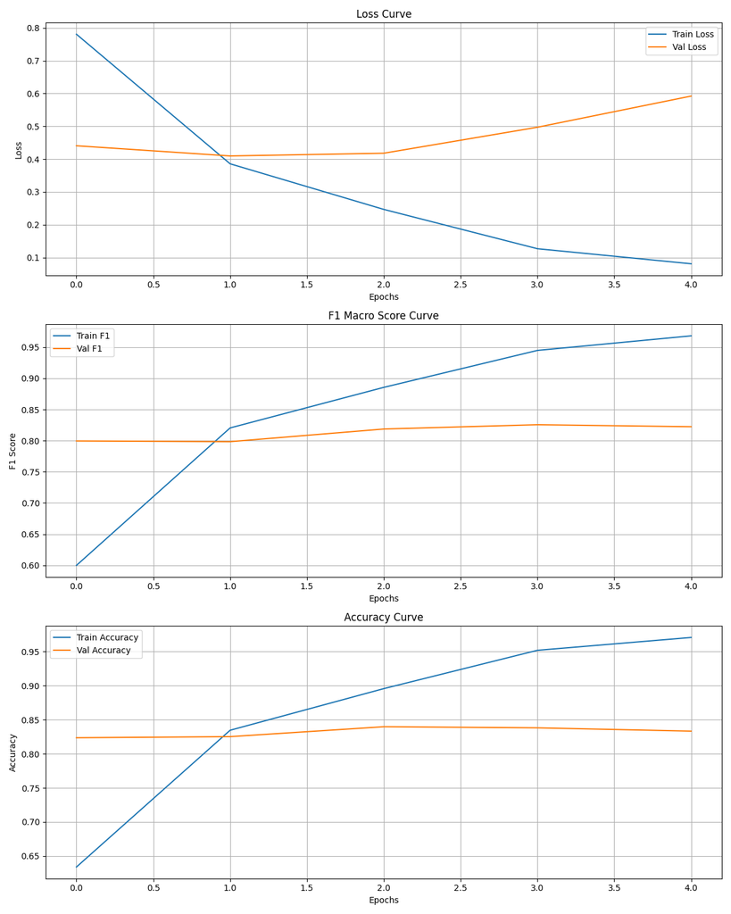

bert_f1_learning_curves.png

gpt plot:

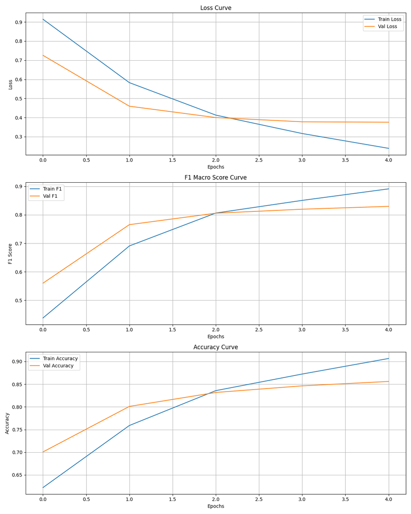

gpt_f1_learning_curves.png

gru plot:

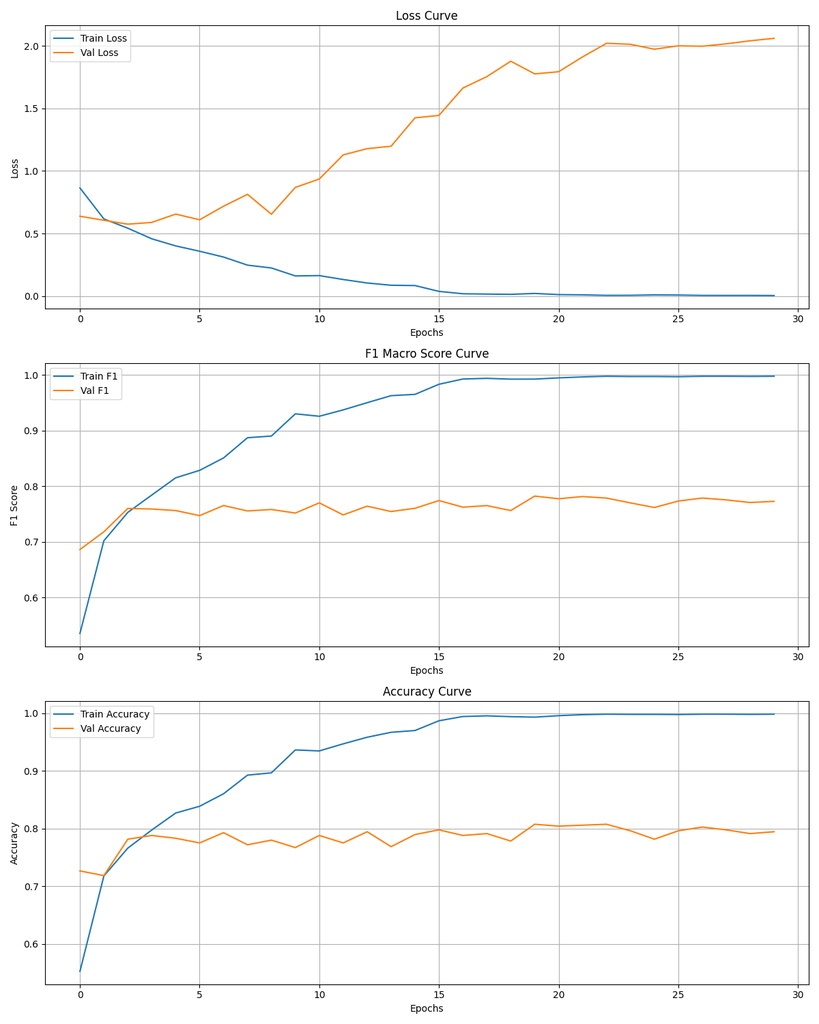

gru_f1_learning_curves.png

rnn plot:

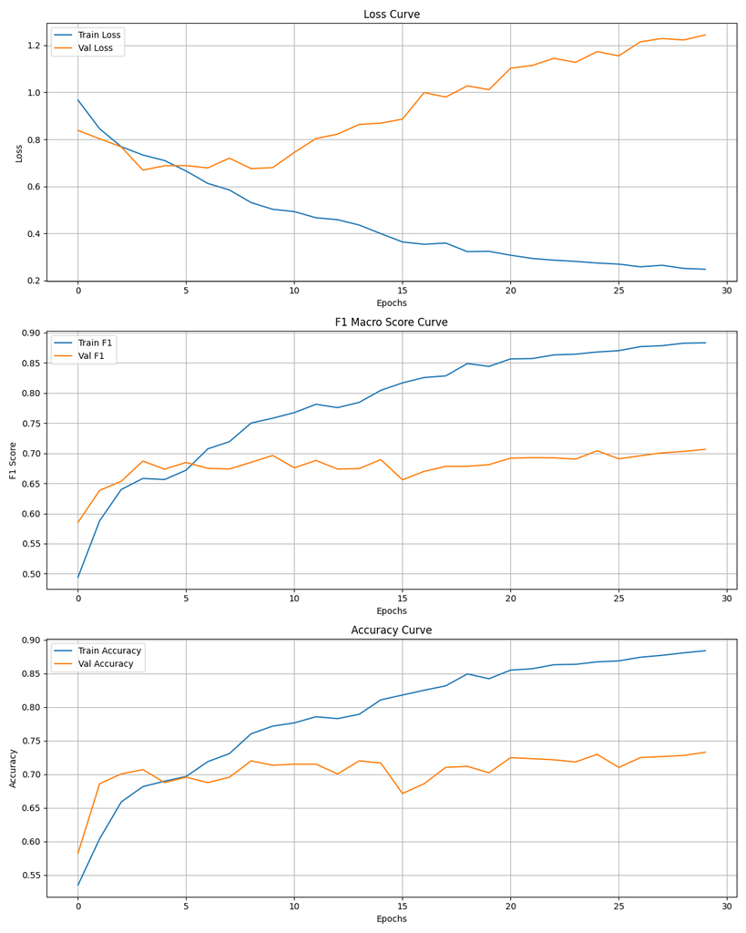

rnn_f1_learning_curves.png

## AI Use Disclosure (Required)

If you used any AI-enabled tools (e.g., ChatGPT, GitHub Copilot, Claude, or other LLM assistants) while working on this assignment, you must disclose that use here. The goal is transparency-not punishment.

In your disclosure, briefly include: - **Tool(s) used:** (name + version if known) - **How you used them:** (e.g., concept explanation, debugging, drafting code, rewriting text) - **What you verified yourself:** (e.g., reran the notebook, checked outputs/plots, checked shapes, read documentation) - **What you did *not* use AI for (if applicable):** (optional)

You are responsible for the correctness of your submission, even if AI suggested code or explanations.